# Incarceration Report

## Overview

This is a brief report regarding incarceration trends in the United States between 1970 and 2018 using Vera Institute’s incarceration data set ([source](https://github.com/vera-institute/incarceration-trends)). The variables that my analysis primarily focuses on are different measures of total jail population (different races), along with the corresponding jail population rates. I also take a look at jail capacity and total jail populations.

## Summary Information

Here, I just chose a brief list of values that I personally was interested in finding. Just to be clear, there isn’t any particular pattern or order to the information presented here; just things I was curious about.

The data reveals that the county and state with the largest Native American jail population in 2016 is San Juan County, NM, with a population of 353. The year with the most overall prison admissions was 2008 at 685286 admissions. The average number of Black prisoners per prison in 2016 was 266. Finally, the total change in U.S prison populations from 2010 to 2018 is about 211877 prisoners.

## Jail Incarceration Rate per Year of Top 5 Louisiana Counties

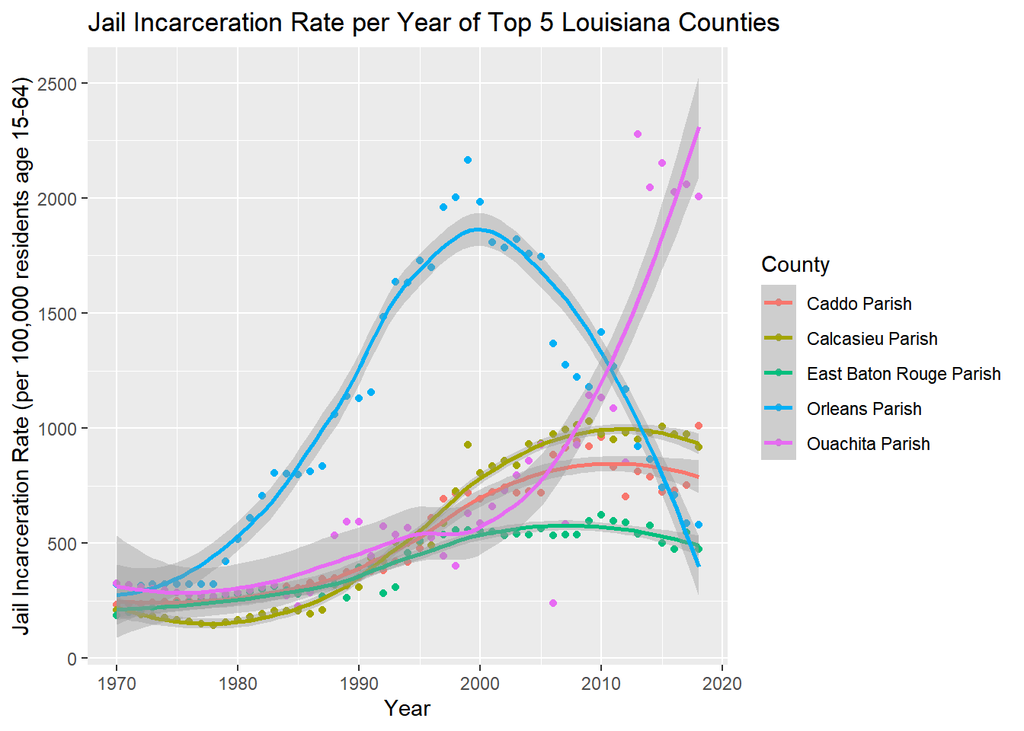

To clarify, the “Top 5 Louisiana Counties” are the top 5 counties by average jail population over the time-horizon of the dataset (1970-2018). I included this chart because I have often heard of Louisiana as a hotspot for crime in the U.S, and wanted to know more about the specific counties. Here are some of the patterns that emerged. Four of the five trend lines showed growth since 1980 before plateauing off and declining at around 2010. Particularly, the Orleans Parish saw dramatic increase in jail incarceration rate since 1980, before rapidly declining in 2000. A possible contributor to the rapid decline includes criminal justice reforms outlined in this [article](https://tinyurl.com/y3352pd5). Finally, Ouachita Parish is the outlier, with continued increases in jail rate, and no marked decline.

## Jail Capacity versus Total Jail Population (2018)

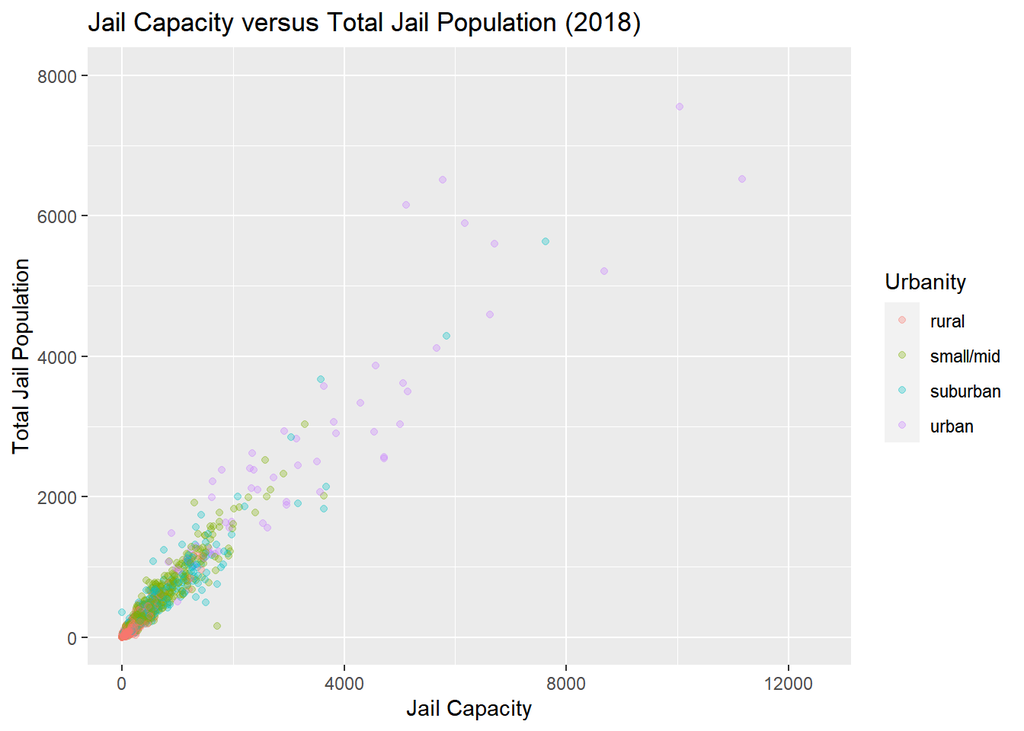

Although the results of the comparison may be mostly as expected, the chart confirms intuition with data. One characteristic that good data scientists have is being skeptical about intuition – and that’s why why I created the chart. I wanted to see how close the relationship between jail capacity and corresponding jail population was. As you can see, the correlation is very strong and clearly linear. Particularly, the data indicates that most jails are used nearly to capacity. This finding conforms to news reports that we often hear about overcrowding of jails in the U.S. Another somewhat expected outcome demonstrated by the chart is that the larger the jail capacity the more likely for it to be located in a a more urban setting.

## Proportion of Blacks in Jail Populations by State (2018)

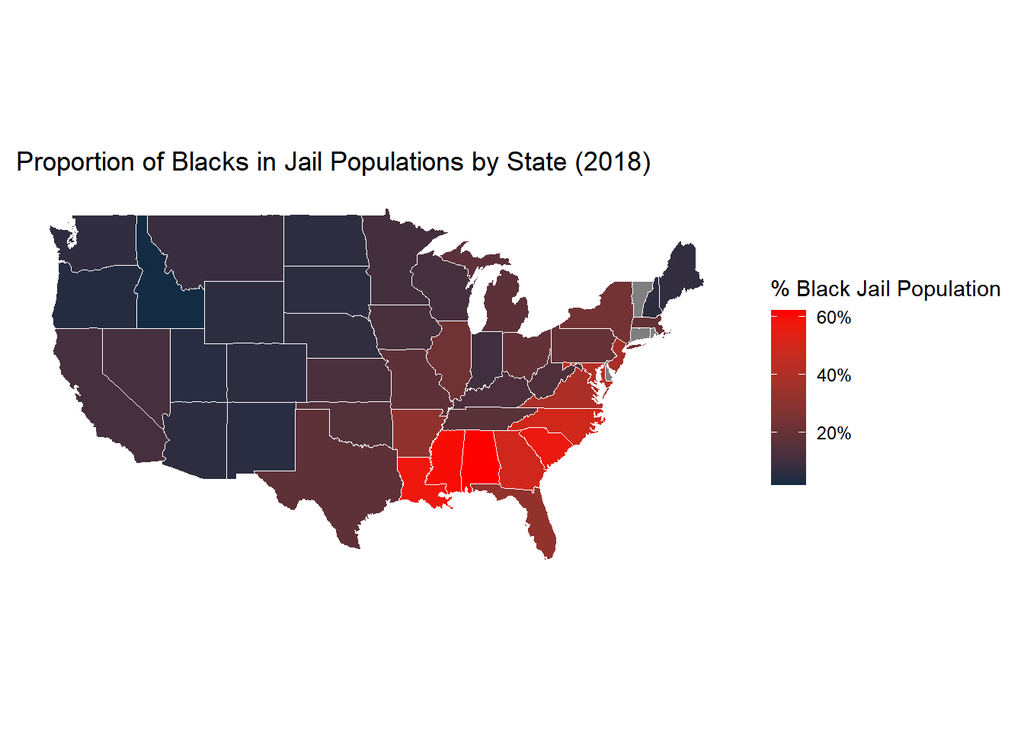